# Analyst Tasks

```r
# load packages
set.seed(9999)
library(tidyverse)
library(readxl)
library(mice)
library(scales)
library(ggrepel)
library(rstatix)
```

**Task 1.**

```r
test_thera <- read_excel('Research Analyst_16SEPT2021.xlsx')
```

**Task 2.**

```r
thera_variable_names <- colnames(test_thera)
thera_variable_names
```

```
##  [1] "patient #"                  "days in the NICU"
##  [3] "age"                        "gender"
##  [5] "hospital code"              "type of surgery"
##  [7] "use of postoperative drain" "entry of paranasal sinus"
##  [9] "CSF leak"                   "duration of operation"
## [11] "diabetes mellitus"          "GCS"
## [13] "SSI"                        "discharge status"
## [15] "glucorticoids"              "lumbar drainage"
## [17] "income bracket"             "systolic bp preoperative"
```

```r
thera_nrow <- nrow(test_thera)
thera_ncol <- ncol(test_thera)
```

**Task 4.**

```r
tail(test_thera$age, n = 6)
```

```
## [1] 21 43 39 37 45 62
```

**Task 5.**

```r
test_thera <- test_thera %>% rename(sex = gender, "blood pressure" = "systolic bp preoperative" )
thera_variable_names <- colnames(test_thera)
```

**Task 6.**

```r
test_thera$`income bracket` = recode(test_thera$`income bracket`,
                                     '1' = '<10,000',
                                     '2' = '10,000 to 20,000',
                                     '3' = '20,001 to 30,000',
                                     '4'='30,001 to 40,000',
                                     '5'='>40,000' )
```

**Task 7.**

```r
head(test_thera$`income bracket`, n= 6)
```

```
## [1] ">40,000"          "10,000 to 20,000" ">40,000"          "10,000 to 20,000"
## [5] "<10,000"          "<10,000"
```

**Task 8.** Seed was generated from no. 9999

Imputations closest to the mean of columns were selected: 58.14 for duration of operation and 137.7 for blood pressure, respectively.

Imputation 2 has the closest mean to duration of operation at 58.42, and the closest mean to blood pressure at 139.2, thus Imputation 2 was selected.

```r
summary(test_thera$`duration of operation`)
```

```
##    Min. 1st Qu.  Median    Mean 3rd Qu.    Max.    NA's
##   32.00   44.00   59.00   58.14   72.00   83.00      12
```

```r
summary(test_thera$`blood pressure`)
```

```
##    Min. 1st Qu.  Median    Mean 3rd Qu.    Max.    NA's
##    98.0   119.0   137.0   137.7   155.0   176.0      34
```

```r
thera_imputed <- select(test_thera, `duration of operation`, `blood pressure`)

# change space to underscore to run through MICE
thera_imputed <- thera_imputed %>% rename(duration_of_operation = "duration of operation",
                                          blood_pressure = "blood pressure")

#Using predictive mean matching method from mice. Generating 5 datasets
thera_imp <- mice(thera_imputed, m= 5, method = c("pmm","pmm"), maxit = 20)
summary(thera_imp$imp$duration_of_operation)
```

```
##        1               2               3              4               5
##  Min.   :35.00   Min.   :39.00   Min.   :33.0   Min.   :43.00   Min.   :33.00
##  1st Qu.:43.00   1st Qu.:49.00   1st Qu.:37.5   1st Qu.:55.25   1st Qu.:52.00
##  Median :58.00   Median :56.50   Median :43.5   Median :60.00   Median :57.50
##  Mean   :55.42   Mean   :58.42   Mean   :48.0   Mean   :60.50   Mean   :59.58
##  3rd Qu.:61.50   3rd Qu.:71.00   3rd Qu.:51.5   3rd Qu.:68.00   3rd Qu.:68.00
##  Max.   :82.00   Max.   :81.00   Max.   :77.0   Max.   :78.00   Max.   :82.00
```

```r
summary(thera_imp$imp$blood_pressure)
```

```
##        1               2               3               4
##  Min.   :105.0   Min.   :100.0   Min.   :104.0   Min.   :108.0
##  1st Qu.:122.0   1st Qu.:125.2   1st Qu.:128.8   1st Qu.:126.0
##  Median :143.0   Median :140.0   Median :142.5   Median :152.5
##  Mean   :139.4   Mean   :139.2   Mean   :145.1   Mean   :144.4
##  3rd Qu.:149.2   3rd Qu.:157.0   3rd Qu.:167.8   3rd Qu.:158.8
##  Max.   :174.0   Max.   :175.0   Max.   :176.0   Max.   :175.0
##        5
##  Min.   :116.0
##  1st Qu.:131.2
##  Median :154.0
##  Mean   :150.3
##  3rd Qu.:174.5
##  Max.   :175.0
```

```r
selected_imp <- complete(thera_imp,2)
summary(selected_imp)
```

```
##  duration_of_operation blood_pressure
##  Min.   :32.00         Min.   : 98.0
##  1st Qu.:44.50         1st Qu.:120.0
##  Median :59.00         Median :137.0
##  Mean   :58.15         Mean   :137.7
##  3rd Qu.:72.00         3rd Qu.:156.0
##  Max.   :83.00         Max.   :176.0
```

**Task 9.**

The 5 chosen variables are discharge status, blood pressure, age, sex, type of surgery

```r
task9_variables <- test_thera %>% select(`blood pressure`, `discharge status`, age, sex, `type of surgery`)

task9_variables <- task9_variables %>% mutate(`discharge status` = as.factor(`discharge status`),
                                              sex = as.factor(sex),
                                              `type of surgery` = as.factor(`type of surgery`))

summary(task9_variables)
```

```
##  blood pressure  discharge status      age            sex
##  Min.   : 98.0   alive:763        Min.   :19.00   female:580
##  1st Qu.:119.0   dead :316        1st Qu.:32.00   male  :499
##  Median :137.0                    Median :44.00
##  Mean   :137.7                    Mean   :44.83
##  3rd Qu.:155.0                    3rd Qu.:59.00
##  Max.   :176.0                    Max.   :72.00
##  NA's   :34
##              type of surgery
##  Burr hole operation :325
##  Craniotomy operation:198
##  Shunt operation     :199
##  Spinal operation    :357
##
##
##
```

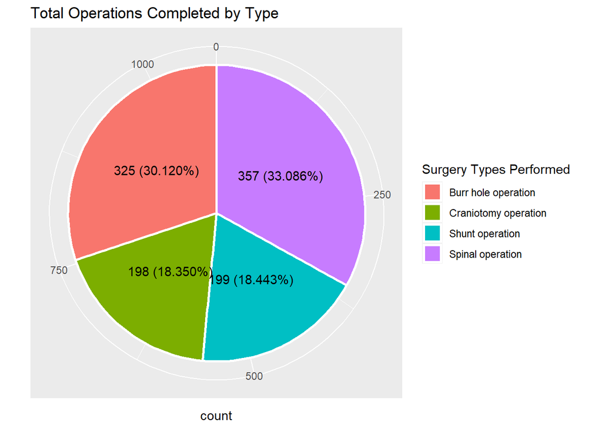

```r
#Type of Surgery
TS_data<-  task9_variables %>% group_by(`type of surgery`)%>% summarise(count = n())

Typeofsurgery_graph<- ggplot(TS_data, aes(x="", y= count, fill=`type of surgery`)) +
geom_bar(stat= "identity",width = 1, color = "white",
size = 1)+ coord_polar("y", start=0) +
geom_text(aes(label = paste0(count," (",
          percent(count / sum(count)),
          ")")), position = position_stack(vjust = 0.5)) +
          ggtitle("Total Operations Completed by Type") +
          scale_fill_discrete(name = "Surgery Types Performed") +
          theme(axis.title.y=element_blank(),  axis.ticks.y=element_blank())

Typeofsurgery_graph
```

```r
#Age and Sex
AS_data <- task9_variables %>% group_by(age, sex) %>% summarise(count=n())
```

[output not shown]

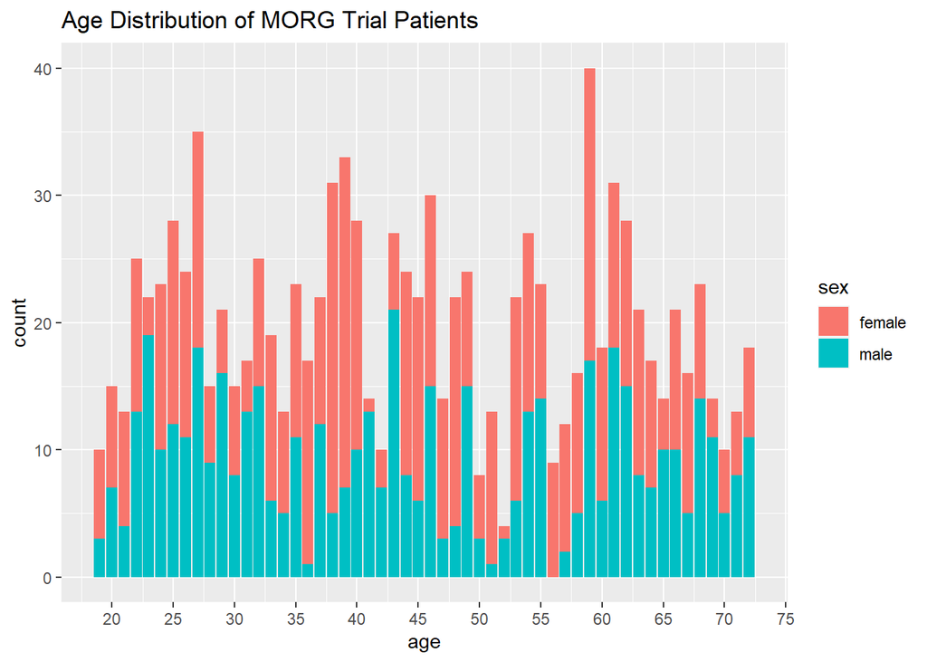

```r
Age_distribution_by_sex <- ggplot(AS_data, aes(x=age, y=count, fill=sex)) +
                                  geom_bar(stat="identity") +
                                  scale_x_continuous(breaks = pretty_breaks(n=9)) +
                                  ggtitle("Age Distribution of MORG Trial Patients")
Age_distribution_by_sex
```

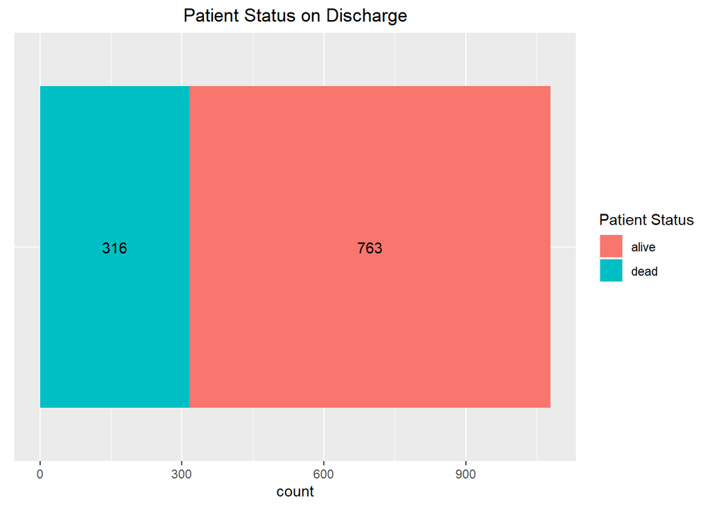

```r
#Discharge Status
DIS_data <- task9_variables %>% group_by(`discharge status`) %>% summarise(count=n())

Discharge_ratio <- ggplot(DIS_data, aes(x="",y=count, fill=`discharge status`)) +
                    geom_bar(stat="identity") +
                    geom_text(aes(label=paste0(count)), position=position_stack(vjust=0.5)) +
                    ggtitle("Patient Status on Discharge") +
                    scale_fill_discrete(name="Patient Status") +
                    theme(plot.title=element_text(hjust = 0.5),
                          axis.title.y=element_blank(),
                          axis.ticks.y=element_blank()) +
                    coord_flip()

Discharge_ratio
```

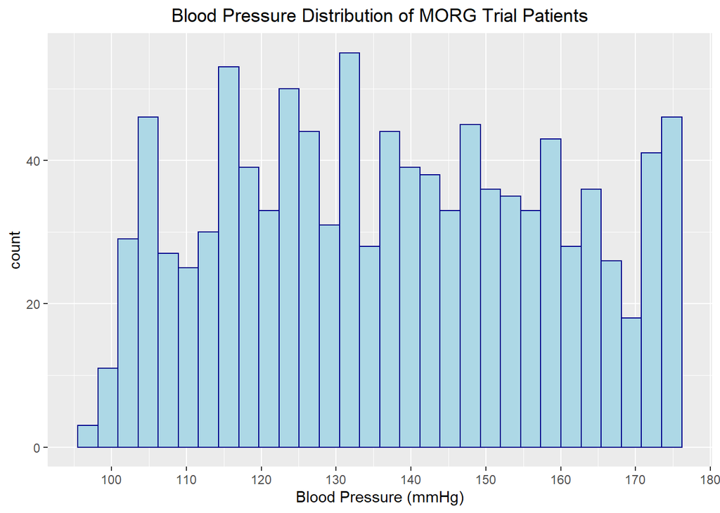

```r
#Blood Pressure

BP_distribution <- ggplot(task9_variables, aes(x=`blood pressure`)) +
                     geom_histogram(color="darkblue", fill="lightblue") +
                     scale_x_continuous(breaks=pretty_breaks(n=9)) +
                     ggtitle("Blood Pressure Distribution of MORG Trial Patients") +
                     theme(plot.title=element_text(hjust=0.5)) +
                     xlab("Blood Pressure (mmHg)")

BP_distribution
```

**Task 10.**

Tested for significant difference between high risk and low risk populations for all variables. To test the difference in means, a t-test was selected for numeric variables, while a chi- squared test was selected for categorical variables. Both tests can help visualize differences between both groups and provide a probability of the significance of the difference.

Significant difference was found between groups for blood pressure, GCS leak, Age, Duration of Operation, Sex, and Lumbar Drainage

```r
test_thera <- test_thera %>% mutate(risk_status = as.factor(case_when(`days in the NICU` <= 2 ~ "low risk",
                                                            `days in the NICU` > 2 ~ "high risk")))
#Performing multiple T-tests.
#T Tests are used for numeric variables
t1<- t_test(test_thera, `blood pressure` ~ risk_status )
t2<- t_test(test_thera, GCS ~ risk_status)
t3<- t_test(test_thera, age ~ risk_status)
t4<- t_test(test_thera, `duration of operation` ~ risk_status)

output_numeric_var <- bind_rows(t1,t2,t3,t4)
output_numeric_var
```

```
## # A tibble: 4 x 8
##   .y.                   group1    group2      n1    n2 statistic    df       p
##   <chr>                 <chr>     <chr>    <int> <int>     <dbl> <dbl>   <dbl>
## 1 blood pressure        high risk low risk   963   116      2.99  142. 0.00326
## 2 GCS                   high risk low risk   963   116     -2.87  146. 0.00473
## 3 age                   high risk low risk   963   116      3.23  150. 0.00155
## 4 duration of operation high risk low risk   963   116     -2.78  173. 0.00604
```

```r
#Chi SQ Tests used for categorical variables
chisq.test(test_thera$risk_status,test_thera$`income bracket`)
```

```
##
##  Pearson's Chi-squared test
##
## data:  test_thera$risk_status and test_thera$`income bracket`
## X-squared = 3.9057, df = 4, p-value = 0.4189
```

```r
chisq.test(test_thera$risk_status,test_thera$`diabetes mellitus`)
```

```
##
##  Pearson's Chi-squared test with Yates' continuity correction
##
## data:  test_thera$risk_status and test_thera$`diabetes mellitus`
## X-squared = 1.1054, df = 1, p-value = 0.2931
```

```r
chisq.test(test_thera$risk_status,test_thera$`CSF leak`)
```

```
##
##  Pearson's Chi-squared test with Yates' continuity correction
##
## data:  test_thera$risk_status and test_thera$`CSF leak`
## X-squared = 3.5176, df = 1, p-value = 0.06072
```

```r
chisq.test(test_thera$risk_status,test_thera$`type of surgery`)
```

```
##
##  Pearson's Chi-squared test
##
## data:  test_thera$risk_status and test_thera$`type of surgery`
## X-squared = 1.0482, df = 3, p-value = 0.7896
```

```r
chisq.test(test_thera$risk_status,test_thera$sex)
```

```
##
##  Pearson's Chi-squared test with Yates' continuity correction
##
## data:  test_thera$risk_status and test_thera$sex
## X-squared = 6.7149, df = 1, p-value = 0.009561
```

```r
chisq.test(test_thera$risk_status,test_thera$`discharge status`)
```

```
##
##  Pearson's Chi-squared test with Yates' continuity correction
##
## data:  test_thera$risk_status and test_thera$`discharge status`
## X-squared = 0.10887, df = 1, p-value = 0.7414
```

```r
chisq.test(test_thera$risk_status,test_thera$`glucorticoids`)
```

```
##
##  Pearson's Chi-squared test with Yates' continuity correction
##
## data:  test_thera$risk_status and test_thera$glucorticoids
## X-squared = 0.19235, df = 1, p-value = 0.661
```

```r
chisq.test(test_thera$risk_status,test_thera$`SSI`)
```

```
##
##  Pearson's Chi-squared test with Yates' continuity correction
##
## data:  test_thera$risk_status and test_thera$SSI
## X-squared = 0.018596, df = 1, p-value = 0.8915
```

```r
chisq.test(test_thera$risk_status,test_thera$`lumbar drainage`)
```

```
##
##  Pearson's Chi-squared test with Yates' continuity correction
##
## data:  test_thera$risk_status and test_thera$`lumbar drainage`
## X-squared = 14.479, df = 1, p-value = 0.0001417
```

```r
chisq.test(test_thera$risk_status,test_thera$`entry of paranasal sinus`)
```

```
##
##  Pearson's Chi-squared test with Yates' continuity correction
##
## data:  test_thera$risk_status and test_thera$`entry of paranasal sinus`
## X-squared = 3.1003, df = 1, p-value = 0.07828
```

**Task 11.**

Univariate Results: As variables: 1. Type of Surgery, Use of Post-Operative Drain, Entry into paranasal sinus, diabetes mellitus, SSI, discharge status, glucorticoids, income bracket were not significant at a 0.05 critical level and will be excluded from the multivariate model

2. Age, sex,csf, duration of operation, GCS leak, lumbar drainage, blood pressure were significant at a 0.05 critical level and will be included in the multivariate model

For sake of cleanliness, variable interactions were not included in the multivariate model.

Final Model Results: An increase in age, being a male, having lumbar drainage used, and an increase in blood pressure all contribute to a higher risk of being placed in the “high-risk” status. However, an increase in the duration of operation does not contribute to a higher risk of being placed in the “high-risk status” in the model.

```r
#Turned risk status into binary variable
test_thera$risk_status_binary <- ifelse(test_thera$risk_status == "high risk", 1, 0)

#Logarithmic Regression will be used as Risk Status is a Binary Variable

model_age <- glm(risk_status_binary ~ age, data = test_thera, family = binomial)
summary(model_age)$coef
```

```
##               Estimate  Std. Error  z value     Pr(>|z|)
## (Intercept) 1.25386412 0.293911468 4.266129 1.988942e-05
## age         0.02003854 0.006704003 2.989041 2.798547e-03
```

```r
model_sex <- glm(risk_status_binary ~ sex, data = test_thera, family = binomial)
summary(model_sex)$coef
```

```
##              Estimate Std. Error  z value     Pr(>|z|)
## (Intercept) 1.8918429  0.1230529 15.37422 2.437544e-53
## sexmale     0.5483278  0.2057198  2.66541 7.689440e-03
```

```r
model_surg <- glm(risk_status_binary ~ `type of surgery`, data = test_thera, family = binomial)
summary(model_surg)$coef
```

```
##                                          Estimate Std. Error    z value
## (Intercept)                            2.18024623  0.1836381 11.8725146
## `type of surgery`Craniotomy operation -0.04861894  0.2949358 -0.1648458
## `type of surgery`Shunt operation       0.06827160  0.3031417  0.2252135
## `type of surgery`Spinal operation     -0.19205336  0.2452817 -0.7829911
##                                           Pr(>|z|)
## (Intercept)                           1.644491e-32
## `type of surgery`Craniotomy operation 8.690653e-01
## `type of surgery`Shunt operation      8.218132e-01
## `type of surgery`Spinal operation     4.336323e-01
```

```r
model_drain <- glm(risk_status_binary ~ `use of postoperative drain`, data = test_thera, family = binomial)
summary(model_drain)$coef
```

```
##                                   Estimate Std. Error    z value     Pr(>|z|)
## (Intercept)                      2.0780361  0.1124359 18.4819674 2.884680e-76
## `use of postoperative drain`used 0.1555561  0.2315982  0.6716639 5.017977e-01
```

```r
model_sinus <- glm(risk_status_binary ~ `entry of paranasal sinus`, data = test_thera, family = binomial)
summary(model_sinus)$coef
```

```
##                                    Estimate Std. Error   z value     Pr(>|z|)
## (Intercept)                       1.9875481  0.1163447 17.083276 1.977018e-65
## `entry of paranasal sinus`present 0.4046491  0.2182733  1.853865 6.375850e-02
```

```r
model_csf <- glm(risk_status_binary ~ `CSF leak`, data = test_thera, family = binomial)
summary(model_csf)$coef
```

```
##                    Estimate Std. Error   z value     Pr(>|z|)
## (Intercept)       1.8528197  0.1603325 11.556109 6.875429e-31
## `CSF leak`present 0.4006934  0.2031405  1.972494 4.855322e-02
```

```r
model_duration <- glm(risk_status_binary ~ `duration of operation`, data = test_thera, family = binomial)
summary(model_duration)$coef
```

```
##                            Estimate  Std. Error   z value     Pr(>|z|)
## (Intercept)              2.95450294 0.413419407  7.146503 8.901660e-13
## `duration of operation` -0.01431513 0.006616515 -2.163545 3.049927e-02
```

```r
model_diabetes <- glm(risk_status_binary ~ `diabetes mellitus`, data = test_thera, family = binomial)
summary(model_diabetes)$coef
```

```
##                              Estimate Std. Error   z value     Pr(>|z|)
## (Intercept)                 2.2490008  0.1550045 14.509260 1.058560e-47
## `diabetes mellitus`present -0.2302955  0.2005225 -1.148477 2.507717e-01
```

```r
model_gcs <- glm(risk_status_binary ~ `GCS`, data = test_thera, family = binomial)
summary(model_gcs)$coef
```

```
##                Estimate Std. Error   z value     Pr(>|z|)
## (Intercept)  2.67974409 0.23546779 11.380512 5.229167e-30
## GCS         -0.06437476 0.02318973 -2.776004 5.503159e-03
```

```r
model_ssi <- glm(risk_status_binary ~ `SSI`, data = test_thera, family = binomial)
summary(model_ssi)$coef
```

```
##               Estimate Std. Error    z value     Pr(>|z|)
## (Intercept)  2.1400662  0.1412661 15.1491846 7.671247e-52
## SSIpostive  -0.0461466  0.1966599 -0.2346519 8.144790e-01
```

```r
model_discharge <- glm(risk_status_binary ~ `discharge status`, data = test_thera, family = binomial)
summary(model_discharge)$coef
```

```
##                           Estimate Std. Error    z value     Pr(>|z|)
## (Intercept)             2.14446822  0.1181641 18.1482194 1.326310e-73
## `discharge status`dead -0.09319755  0.2128635 -0.4378277 6.615112e-01
```

```r
model_glucorticoids <- glm(risk_status_binary ~ `glucorticoids`, data = test_thera, family = binomial)
summary(model_glucorticoids)$coef
```

```
##                    Estimate Std. Error    z value     Pr(>|z|)
## (Intercept)       2.0649934  0.1359106 15.1937619 3.889427e-52
## glucorticoidsused 0.1056175  0.1967882  0.5367064 5.914704e-01
```

```r
model_lumbar <- glm(risk_status_binary ~ `lumbar drainage`, data = test_thera, family = binomial)
summary(model_lumbar)$coef
```

```
##                        Estimate Std. Error   z value     Pr(>|z|)
## (Intercept)           1.7597201  0.1258535 13.982294 1.999390e-44
## `lumbar drainage`used 0.7811317  0.2037762  3.833282 1.264446e-04
```

```r
model_income <- glm(risk_status_binary ~ `income bracket`, data = test_thera, family = binomial)
summary(model_income)$coef
```

```
##                                     Estimate Std. Error    z value     Pr(>|z|)
## (Intercept)                       2.11844370  0.2256524  9.3880822 6.110266e-21
## `income bracket`>40,000           0.16393869  0.3256088  0.5034836 6.146243e-01
## `income bracket`10,000 to 20,000  0.31516966  0.3513312  0.8970728 3.696801e-01
## `income bracket`20,001 to 30,000 -0.06946137  0.3099575 -0.2240996 8.226798e-01
## `income bracket`30,001 to 40,000 -0.25573249  0.2913709 -0.8776872 3.801135e-01
```

```r
model_bp <- glm(risk_status_binary ~ `blood pressure`, data = test_thera, family = binomial)
summary(model_bp)$coef
```

```
##                   Estimate  Std. Error   z value    Pr(>|z|)
## (Intercept)      0.1840405 0.638736417 0.2881321 0.773245627
## `blood pressure` 0.0141795 0.004756907 2.9808237 0.002874743
```

```r
task11_model <- glm(risk_status_binary ~ age + sex + `CSF leak` +`duration of operation`+ GCS + `lumbar drainage` + `blood pressure`, data = test_thera, family = binomial)

summary(task11_model)$coef
```

```
##                            Estimate  Std. Error     z value     Pr(>|z|)
## (Intercept)              0.08687903 0.875646324  0.09921704 0.9209659493
## age                      0.01939688 0.007057499  2.74840759 0.0059885514
## sexmale                  0.50750606 0.212321840  2.39026782 0.0168360905
## `CSF leak`present        0.23192187 0.212053676  1.09369416 0.2740891370
## `duration of operation` -0.01543979 0.006883461 -2.24302735 0.0248950508
## GCS                     -0.05727002 0.024249561 -2.36169290 0.0181917051
## `lumbar drainage`used    0.81680316 0.212712941  3.83993170 0.0001230685
## `blood pressure`         0.01377594 0.004851916  2.83927845 0.0045215681
```

```r
task11_finalmodel <- glm(risk_status_binary ~ age + sex  +`duration of operation` + `lumbar drainage` + `blood pressure`, data = test_thera, family = binomial)

#Final Model
summary(task11_finalmodel)$coef
```

```
##                            Estimate  Std. Error    z value     Pr(>|z|)
## (Intercept)             -0.31534840 0.840493265 -0.3751944 7.075159e-01
## age                      0.02002652 0.007027395  2.8497787 4.374966e-03
## sexmale                  0.53639792 0.211376185  2.5376460 1.116008e-02
## `duration of operation` -0.01650385 0.006864558 -2.4042118 1.620738e-02
## `lumbar drainage`used    0.83451186 0.211562613  3.9445148 7.996171e-05
## `blood pressure`         0.01426849 0.004818364  2.9612723 3.063710e-03
```